# Optimal Treatment Analysis

## Outcome Variable

**Outcome Variable:** haz

## Predictor Variables

**Intervention Variable:** perdiar6

**Adjustment Set:**

- arm
- sex
- W_mage
- meducyrs
- W_mhtcm
- W_mwtkg
- W_mbmi
- W_birthwt
- W_birthlen
- W_nrooms
- month
- brthmon
- impfloor
- impsan
- safeh20
- delta_W_mage
- delta_meducyrs
- delta_W_mhtcm
- delta_W_mwtkg
- delta_W_mbmi
- delta_W_birthwt
- delta_W_birthlen
- delta_W_nrooms
- delta_month
- delta_brthmon
- delta_impfloor
- delta_impsan
- delta_safeh20

## Stratifying Variables

The analysis was stratified on these variable(s):

- agecat
- studyid
- country

## Data Summary

| agecat | studyid | country | perdiar6 | n_cell | n |
| --- | --- | --- | --- | --- | --- |
| Birth | ki0047075b-MAL-ED | BANGLADESH | (0%, 5%] | 96 | 257 |
| Birth | ki0047075b-MAL-ED | BANGLADESH | 0% | 86 | 257 |
| Birth | ki0047075b-MAL-ED | BANGLADESH | >5% | 75 | 257 |
| Birth | ki0047075b-MAL-ED | BRAZIL | (0%, 5%] | 13 | 191 |
| Birth | ki0047075b-MAL-ED | BRAZIL | 0% | 176 | 191 |
| Birth | ki0047075b-MAL-ED | BRAZIL | >5% | 2 | 191 |
| Birth | ki0047075b-MAL-ED | INDIA | (0%, 5%] | 109 | 206 |
| Birth | ki0047075b-MAL-ED | INDIA | 0% | 47 | 206 |
| Birth | ki0047075b-MAL-ED | INDIA | >5% | 50 | 206 |
| Birth | ki0047075b-MAL-ED | NEPAL | (0%, 5%] | 57 | 173 |
| Birth | ki0047075b-MAL-ED | NEPAL | 0% | 60 | 173 |
| Birth | ki0047075b-MAL-ED | NEPAL | >5% | 56 | 173 |
| Birth | ki0047075b-MAL-ED | PERU | (0%, 5%] | 88 | 287 |
| Birth | ki0047075b-MAL-ED | PERU | 0% | 83 | 287 |
| Birth | ki0047075b-MAL-ED | PERU | >5% | 116 | 287 |
| Birth | ki0047075b-MAL-ED | SOUTH AFRICA | (0%, 5%] | 50 | 252 |
| Birth | ki0047075b-MAL-ED | SOUTH AFRICA | 0% | 193 | 252 |
| Birth | ki0047075b-MAL-ED | SOUTH AFRICA | >5% | 9 | 252 |
| Birth | ki0047075b-MAL-ED | TANZANIA, UNITED REPUBLIC OF | (0%, 5%] | 42 | 123 |
| Birth | ki0047075b-MAL-ED | TANZANIA, UNITED REPUBLIC OF | 0% | 60 | 123 |
| Birth | ki0047075b-MAL-ED | TANZANIA, UNITED REPUBLIC OF | >5% | 21 | 123 |
| Birth | ki1000109-ResPak | PAKISTAN | (0%, 5%] | 2 | 6 |
| Birth | ki1000109-ResPak | PAKISTAN | 0% | 1 | 6 |
| Birth | ki1000109-ResPak | PAKISTAN | >5% | 3 | 6 |
| Birth | ki1017093-NIH-Birth | BANGLADESH | (0%, 5%] | 3 | 26 |
| Birth | ki1017093-NIH-Birth | BANGLADESH | 0% | 4 | 26 |
| Birth | ki1017093-NIH-Birth | BANGLADESH | >5% | 19 | 26 |
| Birth | ki1017093c-NIH-Crypto | BANGLADESH | (0%, 5%] | 7 | 27 |
| Birth | ki1017093c-NIH-Crypto | BANGLADESH | 0% | 8 | 27 |
| Birth | ki1017093c-NIH-Crypto | BANGLADESH | >5% | 12 | 27 |

[output cut: 102 more lines]

The following strata were considered:

- agecat: 24 months, studyid: ki0047075b-MAL-ED, country: BANGLADESH
- agecat: 24 months, studyid: ki0047075b-MAL-ED, country: BRAZIL
- agecat: 24 months, studyid: ki0047075b-MAL-ED, country: INDIA
- agecat: 24 months, studyid: ki0047075b-MAL-ED, country: NEPAL
- agecat: 24 months, studyid: ki0047075b-MAL-ED, country: PERU
- agecat: 24 months, studyid: ki0047075b-MAL-ED, country: SOUTH AFRICA
- agecat: 24 months, studyid: ki0047075b-MAL-ED, country: TANZANIA, UNITED REPUBLIC OF
- agecat: 24 months, studyid: ki1017093-NIH-Birth, country: BANGLADESH
- agecat: 24 months, studyid: ki1017093b-PROVIDE, country: BANGLADESH
- agecat: 24 months, studyid: ki1017093c-NIH-Crypto, country: BANGLADESH
- agecat: 24 months, studyid: ki1114097-CMIN, country: BANGLADESH
- agecat: 24 months, studyid: ki1114097-CMIN, country: GUINEA-BISSAU
- agecat: 24 months, studyid: ki1114097-CMIN, country: PERU
- agecat: 24 months, studyid: ki1114097-CONTENT, country: PERU
- agecat: 6 months, studyid: ki0047075b-MAL-ED, country: BANGLADESH
- agecat: 6 months, studyid: ki0047075b-MAL-ED, country: BRAZIL
- agecat: 6 months, studyid: ki0047075b-MAL-ED, country: INDIA
- agecat: 6 months, studyid: ki0047075b-MAL-ED, country: NEPAL
- agecat: 6 months, studyid: ki0047075b-MAL-ED, country: PERU
- agecat: 6 months, studyid: ki0047075b-MAL-ED, country: SOUTH AFRICA
- agecat: 6 months, studyid: ki0047075b-MAL-ED, country: TANZANIA, UNITED REPUBLIC OF
- agecat: 6 months, studyid: ki1000109-ResPak, country: PAKISTAN
- agecat: 6 months, studyid: ki1017093-NIH-Birth, country: BANGLADESH
- agecat: 6 months, studyid: ki1017093b-PROVIDE, country: BANGLADESH
- agecat: 6 months, studyid: ki1017093c-NIH-Crypto, country: BANGLADESH
- agecat: 6 months, studyid: ki1114097-CMIN, country: BANGLADESH
- agecat: 6 months, studyid: ki1114097-CMIN, country: BRAZIL
- agecat: 6 months, studyid: ki1114097-CMIN, country: GUINEA-BISSAU
- agecat: 6 months, studyid: ki1114097-CMIN, country: PERU
- agecat: 6 months, studyid: ki1114097-CONTENT, country: PERU
- agecat: Birth, studyid: ki0047075b-MAL-ED, country: BANGLADESH
- agecat: Birth, studyid: ki0047075b-MAL-ED, country: BRAZIL
- agecat: Birth, studyid: ki0047075b-MAL-ED, country: INDIA
- agecat: Birth, studyid: ki0047075b-MAL-ED, country: NEPAL
- agecat: Birth, studyid: ki0047075b-MAL-ED, country: PERU
- agecat: Birth, studyid: ki0047075b-MAL-ED, country: SOUTH AFRICA
- agecat: Birth, studyid: ki0047075b-MAL-ED, country: TANZANIA, UNITED REPUBLIC OF
- agecat: Birth, studyid: ki1000109-ResPak, country: PAKISTAN
- agecat: Birth, studyid: ki1017093-NIH-Birth, country: BANGLADESH
- agecat: Birth, studyid: ki1017093c-NIH-Crypto, country: BANGLADESH
- agecat: Birth, studyid: ki1114097-CMIN, country: BANGLADESH
- agecat: Birth, studyid: ki1114097-CMIN, country: BRAZIL
- agecat: Birth, studyid: ki1114097-CMIN, country: PERU
- agecat: Birth, studyid: ki1114097-CONTENT, country: PERU

### Dropped Strata

Some strata were dropped due to rare outcomes:

- agecat: Birth, studyid: ki0047075b-MAL-ED, country: BRAZIL
- agecat: Birth, studyid: ki1000109-ResPak, country: PAKISTAN
- agecat: Birth, studyid: ki1017093-NIH-Birth, country: BANGLADESH
- agecat: Birth, studyid: ki1114097-CMIN, country: BANGLADESH
- agecat: Birth, studyid: ki1114097-CMIN, country: PERU
- agecat: Birth, studyid: ki1114097-CONTENT, country: PERU
- agecat: 6 months, studyid: ki0047075b-MAL-ED, country: BRAZIL
- agecat: 24 months, studyid: ki0047075b-MAL-ED, country: BRAZIL

## Methods Detail

We’re interested in the causal parameters $E[Y_a]$ for all values of $a \in \mathcal{A}$. These parameters represent the mean outcome if, possibly contrary to fact, we intervened to set all units to have $A=a$. Under the randomization and positivity assumptions, these are identified by the statistical parameters $\psi_a=E_W[E_{Y|A,W}(Y|A=a,W)]$. In addition, we’re interested in the mean of $Y$, $E[Y]$ under no intervention (the observed mean). We will estimate these parameters by using SuperLearner to fit the relevant likelihood factors – $E_{Y|A,W}(Y|A=a,W)$ and $p(A=a|W)$, and then updating our likelihood fit using a joint TMLE.

For unadjusted analyses ($W=\{\}$), initial likelihoods were estimated using Lrnr_glm to estimate the simple $E(Y|A)$ and Lrnr_mean to estimate $p(A)$. For adjusted analyses, a small library containing Lrnr_glmnet, Lrnr_xgboost, and Lrnr_mean was used.

# Results Detail

## Results Plots

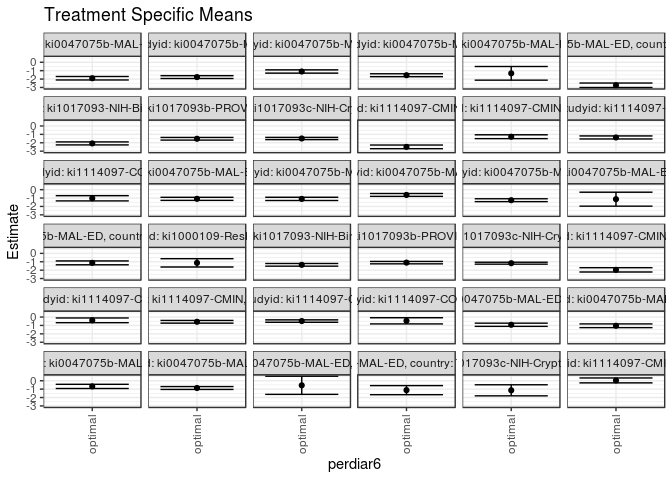

## Results Table

### Parameter: TSM

| agecat | studyid | country | intervention_level | baseline_level | estimate | ci_lower | ci_upper |
| --- | --- | --- | --- | --- | --- | --- | --- |
| Birth | ki0047075b-MAL-ED | BANGLADESH | optimal | observed | -0.9196827 | -1.1128992 | -0.7264663 |
| Birth | ki0047075b-MAL-ED | INDIA | optimal | observed | -1.0386434 | -1.2600195 | -0.8172673 |
| Birth | ki0047075b-MAL-ED | NEPAL | optimal | observed | -0.6758559 | -0.9270674 | -0.4246444 |
| Birth | ki0047075b-MAL-ED | PERU | optimal | observed | -0.8653090 | -1.0374656 | -0.6931524 |
| Birth | ki0047075b-MAL-ED | SOUTH AFRICA | optimal | observed | -0.5447198 | -1.6232077 | 0.5337681 |
| Birth | ki0047075b-MAL-ED | TANZANIA, UNITED REPUBLIC OF | optimal | observed | -1.1208788 | -1.6635327 | -0.5782250 |
| Birth | ki1017093c-NIH-Crypto | BANGLADESH | optimal | observed | -1.1369220 | -1.7958732 | -0.4779707 |
| Birth | ki1114097-CMIN | BRAZIL | optimal | observed | 0.0371826 | -0.2528198 | 0.3271850 |
| 6 months | ki0047075b-MAL-ED | BANGLADESH | optimal | observed | -1.0923672 | -1.2754794 | -0.9092550 |
| 6 months | ki0047075b-MAL-ED | INDIA | optimal | observed | -1.1001124 | -1.2936983 | -0.9065265 |
| 6 months | ki0047075b-MAL-ED | NEPAL | optimal | observed | -0.6273262 | -0.7990087 | -0.4556438 |
| 6 months | ki0047075b-MAL-ED | PERU | optimal | observed | -1.2566539 | -1.4285268 | -1.0847810 |
| 6 months | ki0047075b-MAL-ED | SOUTH AFRICA | optimal | observed | -1.1348772 | -1.9669492 | -0.3028052 |
| 6 months | ki0047075b-MAL-ED | TANZANIA, UNITED REPUBLIC OF | optimal | observed | -1.1341123 | -1.3644218 | -0.9038028 |
| 6 months | ki1000109-ResPak | PAKISTAN | optimal | observed | -1.1312186 | -1.6248873 | -0.6375498 |
| 6 months | ki1017093-NIH-Birth | BANGLADESH | optimal | observed | -1.3669989 | -1.5238283 | -1.2101695 |
| 6 months | ki1017093b-PROVIDE | BANGLADESH | optimal | observed | -1.1046538 | -1.2458634 | -0.9634442 |
| 6 months | ki1017093c-NIH-Crypto | BANGLADESH | optimal | observed | -1.1726482 | -1.2862832 | -1.0590133 |
| 6 months | ki1114097-CMIN | BANGLADESH | optimal | observed | -1.9646424 | -2.2219806 | -1.7073042 |
| 6 months | ki1114097-CMIN | BRAZIL | optimal | observed | -0.3904981 | -0.6729984 | -0.1079978 |
| 6 months | ki1114097-CMIN | GUINEA-BISSAU | optimal | observed | -0.5657078 | -0.7260066 | -0.4054090 |
| 6 months | ki1114097-CMIN | PERU | optimal | observed | -0.4794333 | -0.6214139 | -0.3374527 |
| 6 months | ki1114097-CONTENT | PERU | optimal | observed | -0.4482806 | -0.8146164 | -0.0819448 |
| 24 months | ki0047075b-MAL-ED | BANGLADESH | optimal | observed | -1.9015485 | -2.1085786 | -1.6945184 |
| 24 months | ki0047075b-MAL-ED | INDIA | optimal | observed | -1.7640410 | -1.9328132 | -1.5952688 |
| 24 months | ki0047075b-MAL-ED | NEPAL | optimal | observed | -1.0998438 | -1.2937973 | -0.9058903 |
| 24 months | ki0047075b-MAL-ED | PERU | optimal | observed | -1.5410272 | -1.7131249 | -1.3689296 |
| 24 months | ki0047075b-MAL-ED | SOUTH AFRICA | optimal | observed | -1.3168264 | -2.1297801 | -0.5038727 |
| 24 months | ki0047075b-MAL-ED | TANZANIA, UNITED REPUBLIC OF | optimal | observed | -2.7397123 | -3.0060864 | -2.4733382 |
| 24 months | ki1017093-NIH-Birth | BANGLADESH | optimal | observed | -2.0769479 | -2.2577873 | -1.8961085 |
| 24 months | ki1017093b-PROVIDE | BANGLADESH | optimal | observed | -1.5253496 | -1.6837241 | -1.3669751 |
| 24 months | ki1017093c-NIH-Crypto | BANGLADESH | optimal | observed | -1.4903375 | -1.6243869 | -1.3562881 |
| 24 months | ki1114097-CMIN | BANGLADESH | optimal | observed | -2.4899665 | -2.7073487 | -2.2725843 |
| 24 months | ki1114097-CMIN | GUINEA-BISSAU | optimal | observed | -1.2800263 | -1.5079567 | -1.0520959 |
| 24 months | ki1114097-CMIN | PERU | optimal | observed | -1.3674843 | -1.5478555 | -1.1871132 |
| 24 months | ki1114097-CONTENT | PERU | optimal | observed | -1.0289341 | -1.3411067 | -0.7167616 |

### Parameter: E(Y)

| agecat | studyid | country | intervention_level | baseline_level | estimate | ci_lower | ci_upper |
| --- | --- | --- | --- | --- | --- | --- | --- |
| Birth | ki0047075b-MAL-ED | BANGLADESH | observed | observed | -1.0843969 | -1.2100768 | -0.9587169 |
| Birth | ki0047075b-MAL-ED | INDIA | observed | observed | -1.0106311 | -1.1499962 | -0.8712660 |
| Birth | ki0047075b-MAL-ED | NEPAL | observed | observed | -0.7089017 | -0.8656064 | -0.5521971 |
| Birth | ki0047075b-MAL-ED | PERU | observed | observed | -0.9322300 | -1.0461262 | -0.8183337 |
| Birth | ki0047075b-MAL-ED | SOUTH AFRICA | observed | observed | -0.7068651 | -0.8323249 | -0.5814053 |
| Birth | ki0047075b-MAL-ED | TANZANIA, UNITED REPUBLIC OF | observed | observed | -0.9338211 | -1.1465079 | -0.7211344 |
| Birth | ki1017093c-NIH-Crypto | BANGLADESH | observed | observed | -1.1100000 | -1.5086894 | -0.7113106 |
| Birth | ki1114097-CMIN | BRAZIL | observed | observed | 0.0576522 | -0.1471825 | 0.2624869 |
| 6 months | ki0047075b-MAL-ED | BANGLADESH | observed | observed | -1.2056777 | -1.3231497 | -1.0882058 |
| 6 months | ki0047075b-MAL-ED | INDIA | observed | observed | -1.2203672 | -1.3387619 | -1.1019726 |
| 6 months | ki0047075b-MAL-ED | NEPAL | observed | observed | -0.5610593 | -0.6737915 | -0.4483272 |
| 6 months | ki0047075b-MAL-ED | PERU | observed | observed | -1.3268010 | -1.4351217 | -1.2184802 |
| 6 months | ki0047075b-MAL-ED | SOUTH AFRICA | observed | observed | -1.0633760 | -1.1911088 | -0.9356432 |
| 6 months | ki0047075b-MAL-ED | TANZANIA, UNITED REPUBLIC OF | observed | observed | -1.3601215 | -1.4821830 | -1.2380600 |
| 6 months | ki1000109-ResPak | PAKISTAN | observed | observed | -1.4029220 | -1.6085859 | -1.1972581 |
| 6 months | ki1017093-NIH-Birth | BANGLADESH | observed | observed | -1.4073821 | -1.4960598 | -1.3187043 |
| 6 months | ki1017093b-PROVIDE | BANGLADESH | observed | observed | -1.0871041 | -1.1635539 | -1.0106543 |
| 6 months | ki1017093c-NIH-Crypto | BANGLADESH | observed | observed | -1.1986783 | -1.2700937 | -1.1272630 |
| 6 months | ki1114097-CMIN | BANGLADESH | observed | observed | -1.7844376 | -1.9222926 | -1.6465825 |
| 6 months | ki1114097-CMIN | BRAZIL | observed | observed | -0.6841667 | -0.8870073 | -0.4813261 |
| 6 months | ki1114097-CMIN | GUINEA-BISSAU | observed | observed | -0.6242708 | -0.7083402 | -0.5402014 |
| 6 months | ki1114097-CMIN | PERU | observed | observed | -0.5133753 | -0.5929878 | -0.4337629 |
| 6 months | ki1114097-CONTENT | PERU | observed | observed | -0.3139217 | -0.4868486 | -0.1409948 |
| 24 months | ki0047075b-MAL-ED | BANGLADESH | observed | observed | -1.9431132 | -2.0691678 | -1.8170586 |
| 24 months | ki0047075b-MAL-ED | INDIA | observed | observed | -1.8458150 | -1.9718703 | -1.7197596 |
| 24 months | ki0047075b-MAL-ED | NEPAL | observed | observed | -1.2752193 | -1.3954783 | -1.1549603 |
| 24 months | ki0047075b-MAL-ED | PERU | observed | observed | -1.7500995 | -1.8705474 | -1.6296516 |
| 24 months | ki0047075b-MAL-ED | SOUTH AFRICA | observed | observed | -1.6228361 | -1.7581177 | -1.4875546 |
| 24 months | ki0047075b-MAL-ED | TANZANIA, UNITED REPUBLIC OF | observed | observed | -2.6058879 | -2.7403043 | -2.4714714 |
| 24 months | ki1017093-NIH-Birth | BANGLADESH | observed | observed | -2.1807945 | -2.2835902 | -2.0779987 |
| 24 months | ki1017093b-PROVIDE | BANGLADESH | observed | observed | -1.5861179 | -1.6693668 | -1.5028689 |
| 24 months | ki1017093c-NIH-Crypto | BANGLADESH | observed | observed | -1.4295331 | -1.5127726 | -1.3462935 |
| 24 months | ki1114097-CMIN | BANGLADESH | observed | observed | -2.5109504 | -2.6361514 | -2.3857494 |
| 24 months | ki1114097-CMIN | GUINEA-BISSAU | observed | observed | -1.5769713 | -1.7148941 | -1.4390486 |
| 24 months | ki1114097-CMIN | PERU | observed | observed | -1.4709290 | -1.5934208 | -1.3484372 |
| 24 months | ki1114097-CONTENT | PERU | observed | observed | -0.6962195 | -0.8674103 | -0.5250287 |

### Parameter: PAR

| agecat | studyid | country | intervention_level | baseline_level | estimate | ci_lower | ci_upper |
| --- | --- | --- | --- | --- | --- | --- | --- |
| Birth | ki0047075b-MAL-ED | BANGLADESH | optimal | observed | -0.1647141 | -0.3291339 | -0.0002944 |
| Birth | ki0047075b-MAL-ED | INDIA | optimal | observed | 0.0280123 | -0.1651734 | 0.2211980 |
| Birth | ki0047075b-MAL-ED | NEPAL | optimal | observed | -0.0330458 | -0.2474139 | 0.1813222 |
| Birth | ki0047075b-MAL-ED | PERU | optimal | observed | -0.0669209 | -0.2147489 | 0.0809071 |
| Birth | ki0047075b-MAL-ED | SOUTH AFRICA | optimal | observed | -0.1621453 | -1.2178767 | 0.8935862 |
| Birth | ki0047075b-MAL-ED | TANZANIA, UNITED REPUBLIC OF | optimal | observed | 0.1870577 | -0.2307133 | 0.6048287 |
| Birth | ki1017093c-NIH-Crypto | BANGLADESH | optimal | observed | 0.0269220 | -0.4683424 | 0.5221863 |
| Birth | ki1114097-CMIN | BRAZIL | optimal | observed | 0.0204696 | -0.1874682 | 0.2284073 |
| 6 months | ki0047075b-MAL-ED | BANGLADESH | optimal | observed | -0.1133105 | -0.2655671 | 0.0389461 |
| 6 months | ki0047075b-MAL-ED | INDIA | optimal | observed | -0.1202548 | -0.2795986 | 0.0390890 |
| 6 months | ki0047075b-MAL-ED | NEPAL | optimal | observed | 0.0662669 | -0.0830410 | 0.2155749 |
| 6 months | ki0047075b-MAL-ED | PERU | optimal | observed | -0.0701471 | -0.2000789 | 0.0597847 |
| 6 months | ki0047075b-MAL-ED | SOUTH AFRICA | optimal | observed | 0.0715012 | -0.7440111 | 0.8870136 |
| 6 months | ki0047075b-MAL-ED | TANZANIA, UNITED REPUBLIC OF | optimal | observed | -0.2260091 | -0.4331092 | -0.0189091 |
| 6 months | ki1000109-ResPak | PAKISTAN | optimal | observed | -0.2717034 | -0.7219730 | 0.1785661 |
| 6 months | ki1017093-NIH-Birth | BANGLADESH | optimal | observed | -0.0403832 | -0.1693526 | 0.0885863 |
| 6 months | ki1017093b-PROVIDE | BANGLADESH | optimal | observed | 0.0175497 | -0.1041145 | 0.1392140 |
| 6 months | ki1017093c-NIH-Crypto | BANGLADESH | optimal | observed | -0.0260301 | -0.1156915 | 0.0636313 |
| 6 months | ki1114097-CMIN | BANGLADESH | optimal | observed | 0.1802048 | -0.0199430 | 0.3803526 |
| 6 months | ki1114097-CMIN | BRAZIL | optimal | observed | -0.2936686 | -0.5514265 | -0.0359106 |
| 6 months | ki1114097-CMIN | GUINEA-BISSAU | optimal | observed | -0.0585630 | -0.1898068 | 0.0726807 |
| 6 months | ki1114097-CMIN | PERU | optimal | observed | -0.0339420 | -0.1553443 | 0.0874602 |
| 6 months | ki1114097-CONTENT | PERU | optimal | observed | 0.1343589 | -0.1840801 | 0.4527980 |
| 24 months | ki0047075b-MAL-ED | BANGLADESH | optimal | observed | -0.0415647 | -0.2116897 | 0.1285602 |
| 24 months | ki0047075b-MAL-ED | INDIA | optimal | observed | -0.0817740 | -0.1978149 | 0.0342669 |
| 24 months | ki0047075b-MAL-ED | NEPAL | optimal | observed | -0.1753755 | -0.3400438 | -0.0107071 |
| 24 months | ki0047075b-MAL-ED | PERU | optimal | observed | -0.2090723 | -0.3477547 | -0.0703899 |
| 24 months | ki0047075b-MAL-ED | SOUTH AFRICA | optimal | observed | -0.3060097 | -1.1044740 | 0.4924546 |
| 24 months | ki0047075b-MAL-ED | TANZANIA, UNITED REPUBLIC OF | optimal | observed | 0.1338244 | -0.0981326 | 0.3657814 |
| 24 months | ki1017093-NIH-Birth | BANGLADESH | optimal | observed | -0.1038466 | -0.2550661 | 0.0473729 |
| 24 months | ki1017093b-PROVIDE | BANGLADESH | optimal | observed | -0.0607683 | -0.1960930 | 0.0745565 |
| 24 months | ki1017093c-NIH-Crypto | BANGLADESH | optimal | observed | 0.0608044 | -0.0480072 | 0.1696160 |
| 24 months | ki1114097-CMIN | BANGLADESH | optimal | observed | -0.0209839 | -0.1940030 | 0.1520353 |
| 24 months | ki1114097-CMIN | GUINEA-BISSAU | optimal | observed | -0.2969450 | -0.5036534 | -0.0902365 |
| 24 months | ki1114097-CMIN | PERU | optimal | observed | -0.1034446 | -0.2537619 | 0.0468727 |
| 24 months | ki1114097-CONTENT | PERU | optimal | observed | 0.3327146 | 0.0694628 | 0.5959664 |